# The student’s guide to independence in R

Sophie Nolden with the help of Isabelle Ehrlich and Amy Li (Descriptive analysis and plots), and Francesco Pupillo (Inferential analysis)

November, 2022

## Introduction

Dear students, In this document, I will provide some tips that are meant to help you to use R independently. Most of you have already worked with R in the ExPra or other courses, and things may have seemed very clear to you back then. However, when you have to create your own analysis script from scratch, you may sometimes be a little lost. I thus summarized a few key points that can help you to find your way in the jungle!

Please make sure that you always try to figure out the solution yourself first. If you are stuck, ask your peers (or your supervisor if your peers cannot help you), and make sure that you provide all the information needed to understand both your question and your first approach to solve the problem.

Enjoy reading!

You should be familiar with some basics in R before you continue. Check out my introductory file.

If you need more input, I suggest to work with an online tutorial of your choice. For example, check out these three ([1](https://djnavarro.github.io/chdss2018/day0/introtoR1-handout.pdf), [2](https://djnavarro.github.io/chdss2018/day0/introtoR2-handout.pdf), [3](https://djnavarro.github.io/chdss2018/day0/introtoR3-handout.pdf)) suggestions on first steps in R. And, last but not least, check out the suggestions on our [lab manual](https://gitlab.com/Soph87/LISCOlab/-/wikis/LISCOLabManual#behavioral-analyses)!

You may also want to checkout the documentation on [R Markdown](https://rmarkdown.rstudio.com/index.html).

You should know the following concepts:

- What is a data frame? How is it different from a matrix?
- How can I access certain data points in a data frame? How can I select certain rows or columns?
- Which classes of data are there?
- What is a function and how is a function different from a script?
- What is a boolean expression?
- Why are there different packages? How can I install packages?

## How do I get started?

Before you write your first line of R code, make sure that you know exactly what you would like to do and how. Here are some examples for very general questions: Do you want to calculate an average? Do you want to make a t-test or rather a calculate a correlation? What are your independent and dependent variables?

Once your general approach is clear, ask yourself more specific questions such as: In which columns of my data frame do I find my independent variables? Do I want to correct for outliers? Which lines should be deleted if I want to exclude practice blocks?  
Just imagine your data frame was a table on a physical sheet of paper and your only tool was a simple calculator. What would be your analysis steps?

Very often, students tell me that they do not know how to handle R, but very soon, I realize that they actually do not know what they want to do! So make sure that every single step of your analysis is clear to you. I suggest to write down your analysis steps into your script (as comments). Once you are done and your concept makes sense to you, you can fill up with actual code. This way, you have already made sure that your documentation is done well, since there should be a balance of 50:50 between comments and code.

Generally speaking, your script should be structured like this:

1. Start your script with a title, your name, and the current date. If your script is based on an older script, provide this information as well.
2. Clean up your global environment.

```r
rm(list = ls())
```

3. Continue with your parameters. These are values that you may eventually want to change and that you do not want to search for in every single line of your script. For example, you write your data path here, or you define the different age groups that you have tested. Just make sure you write your script in such a way that you can use it at multiple occasions (which may become relevant for your master’s thesis).
4. Continue with your actual analysis. Provide some structure and comment everything you do. Documentation is important so that the script is understandable for others, both your collaborators and your future self.

## Where can I get help?

After you gained some basic knowledge in R, you should definitely not expect to sit down in front of your computer and then, magically, your fingers just type down all code. It is a matter of constant improvement, and you will have to learn how to use new functions all the time!  
**It is normal to look up how to do certain things, even if you have dealt with a similar problem before.**  
Here are three main sources of help for your script:

1. Recycle elements from previous scripts. This is actually quite useful because you have already figured it out once before. **Remember to always provide comments on what you are doing in the script, in order to be able to recycle stuff in the future.**
2. Use a search engine of your choice and look up your question in the internet. The community is huge and usually very friendly, and chances are quite high that somebody else has encountered your problem before. (You can also post questions yourself if nobody has asked your questions before, but this will most likely not be the case.) Search in English. I like pages such as stackoverflow and github for helpful discussions.  
   It will take some time until you know how to ask your questions properly. Your first search term should of course be “R”. Use key words from R and psychology, such as “data frame”, “columns”, “outlier”… If you put too many terms into the search window, you will probably get a lot of results that are not related to your question, so try to be precise. When you realize that the answers you get are rather remote from what you actually want, change your search terms.
3. Use the help function in R. This requires some practice and may not always help you when you are new to it. I find it useful for the list of input arguments and the examples provided in the end.

## Common analysis steps

All analyses are of course different, but there are some common analysis steps that we encounter most of the time:

1. Read raw data
2. Clean up and preprocess raw data
3. Aggregate raw data
4. Descriptive analysis and plots

We will go through them step by step.

### I. Read raw data

Getting error messages in R can be frustrating at the beginning. However, it is quite normal, and you will learn to read the error messages such that they can guide you to the solution. Not handling your raw data properly, on the other hand, can lead to REAL PROBLEMS!!!

You have to be super careful with your raw data. Store it at multiple sites on different drives. And NEVER, really **NEVER EVER, write into your raw data directory.** This is why we call our raw data directory sometimes “Holy Folder”, and it must NEVER be touched other than for reading the data so that you can never accidentally overwrite it.

That is why we need an “inPath” and an “outPath”, one directory to read from, one to write into. Create a directory with all participants’ raw data. If you already know that you want to exclude a participant for whatever reason, you can already omit the respective file at this stage. Create a directory called “Analyses” or something similar. Always choose meaningful names and avoid spaces or special characters.

It is very common that there are errors in your paths. In order to avoid typos, I suggest that you browse to your directory and then copy the path from there (e.g., from your browser header, or by selecting the properties of a file in that directory). This can be especially helpful for long and complicated paths. If you use Windows, you may need to change the slashes.  
Make sure that you do not forget the ” “.  
And, last but not least, and that is very often overlooked by beginners: **Do not forget the last slash in the end! ;-)**

You can also set your working directory in R under “Session” -> “Set Working Directory” (to your outPath).

I recommend to never use spaces or special characters in your path. It may be worthwhile renaming your directories. The same is true for all objects/column names/characters you create in R. It is not impossible to handle spaces in R, but it is definitely more troublesome.

Remember that your paths should be defined at the beginning of your file.

##### (An aside about file paths)

It’s easy to see how the specificity of file paths can quickly get annoying and make the script fragile. You are not Bailey, so you will have to change all of the paths in the files for the script to work again. And what if you were working on a script but then you get a new computer? What if you forgot one tiny “/” and now you want to set your computer on fire? And so on and so on.

A package that offers answers to these issues is the here() package. Combined with a logical folder structure, here() can improve the flexibility of your scripts so that neither you nor your collaborators will have to rename another file path again. Anywhere you would use “C:/filepath/blahblah”, you can replace with here(). You can check out a straightforward guide to using it [here] (http://jenrichmond.rbind.io/post/how-to-use-the-here-package/) (no pun intended).

#### Let’s have a look at a few cases that you may run into:

  `library(haven) # This library is useful to deal with SPSS files.'` `SPSSfile <- "myOtherData.sav" # Define the name of your SPSS file.` `myOtherData <- read_sav(paste(inPath, SPSSfile, sep = "")) # Read in SPSS data. Note how I used "paste" to concatenate two character values (your path name and your file name).`
- If you tested mutliple groups (e.g., children, young adults, and older adults), you may want to organize their data in different folders. In this case, I recommend to loop through these folders and add up all files into one single data frame. Just provide a vector of character values as “inPath”, with each character vector representing one path.

  ```r
  # Define inPath
  inPath <- c("/home/soph/Documents/thesis/HolyFolder/Child/"
              , "/home/soph/Documents/thesis/HolyFolder/YA/"
              , "/home/soph/Documents/thesis/HolyFolder/Child/OA/")
  ```

  Next, create an empty data frame with the same amount of columns and the same column name as in your actual raw data.

  `allGroups <- setNames(data.frame(matrix(ncol = 9, nrow = 0))` `, c("participant", "group", "age", "sex", "handedness"` `, "IV1", "IV2", "DV1", "DV2"))`

  Loop through the different directories and read the data from each directory one after another (e.g., into a data frame called “myData”). Add it all to your empty data frame at the end of each iteration.

  `allGroups <- rbind(allGroups, myData)`

  Tip 1 for using loops: Restrict the use of loops to a minimum, since R is not really fast dealing with loops (but it will do it eventually).

  Tip 2 for using loops: Use a meaningful term for the value that changes at each iteration. “val” or “i” are not meaningful, but “iGroup” or “iParticipant” are. This will help you to keep track of what you are actually doing, especially in nested loops.
- In some cases, multiple files per participant are generated and you may want merge the different files. For example, you have one file for a memory encoding session and one file for a memory retrieval session. It can be useful to have the two sessions organized as different columns and each line referring to a specific stimulus. In this case, check out a “merge” function (I like the one from the package “data.table”) in these cases.

Once your data are all in, you should take some time to check if all data looks as it is supposed to be. Are all subjects there? Is the number of lines as expected (this is very often the number of trials by the number of participants). Are all conditions there? Is the number of trials for each condition correct? For this purpose, use the “table” function. Have a look at your “global environment” as well were you can see the dimensions of your data frame.

### II. Clean up and preprocess raw data

Our raw data files are usually organized such that one line contains all information from one trial. However, there may be trials that we do not need such as practice trials. Or there may be empty lines between blocks that we also do not need.

Let’s have a look at the following example:

```r
# Let's create a little example data frame.
example1 <- setNames(data.frame(matrix(ncol = 5, nrow = 10))
                    , c("participant", "OS", "blockNumber", "DV", "IV"))
# Values in columns
example1[1:5,1] <- 5
example1[6:10,1] <- 6
example1[,2] <- as.character("Windows")
example1[,3] <-c(NA,1,1,2,2,NA,1,1,2,2)
example1[,4] <- c(.5,.6,.7,.7,.8,.9,.9,.8,.5,.7)
example1[,5] <- c("B","A","B","B","A","B","B","A","B","A")
example1
```

```
##    participant      OS blockNumber  DV IV
## 1            5 Windows          NA 0.5  B
## 2            5 Windows           1 0.6  A
## 3            5 Windows           1 0.7  B
## 4            5 Windows           2 0.7  B
## 5            5 Windows           2 0.8  A
## 6            6 Windows          NA 0.9  B
## 7            6 Windows           1 0.9  B
## 8            6 Windows           1 0.8  A
## 9            6 Windows           2 0.5  B
## 10           6 Windows           2 0.7  A
```

The column “blockNumber” contains, well, the block number. Lines with NA are practice trials. We can remove them like this:

```r
example1 <- example1[!is.na(example1$blockNumber),] # Check the different parts of this line. What do the "!" and "is.na" do? Also check out the position of the comma in the square brackets. Remember: Zeilen zuerst, Spalten später!
example1
```

```
##    participant      OS blockNumber  DV IV
## 2            5 Windows           1 0.6  A
## 3            5 Windows           1 0.7  B
## 4            5 Windows           2 0.7  B
## 5            5 Windows           2 0.8  A
## 7            6 Windows           1 0.9  B
## 8            6 Windows           1 0.8  A
## 9            6 Windows           2 0.5  B
## 10           6 Windows           2 0.7  A
```

We probably also want to remove the column “OS” because it is not very helpful here. You can select specific columns by index or name, and you can also delete specific columns.

```r
example1_copy <- example1 # Let's create a copy of example1 so we can do the same stuff over and over again.
example1 <- example1[,c(1,3,4,5)] # Select certain columns by index. Check out the position of the comma.
example1
```

```
##    participant blockNumber  DV IV
## 2            5           1 0.6  A
## 3            5           1 0.7  B
## 4            5           2 0.7  B
## 5            5           2 0.8  A
## 7            6           1 0.9  B
## 8            6           1 0.8  A
## 9            6           2 0.5  B
## 10           6           2 0.7  A
```

```r
example1 <- example1_copy # Back to our previous data frame.
example1 <- example1[,c("participant", "blockNumber", "IV", "DV")] # Select certain columns by name.
example1
```

```
##    participant blockNumber IV  DV
## 2            5           1  A 0.6
## 3            5           1  B 0.7
## 4            5           2  B 0.7
## 5            5           2  A 0.8
## 7            6           1  B 0.9
## 8            6           1  A 0.8
## 9            6           2  B 0.5
## 10           6           2  A 0.7
```

```r
example1 <- example1_copy # Back to our previous data frame.
example1$OS <- NULL # Delete a single columns by its name.
example1
```

```
##    participant blockNumber  DV IV
## 2            5           1 0.6  A
## 3            5           1 0.7  B
## 4            5           2 0.7  B
## 5            5           2 0.8  A
## 7            6           1 0.9  B
## 8            6           1 0.8  A
## 9            6           2 0.5  B
## 10           6           2 0.7  A
```

Actually, this would also be a good moment to organize the order of your columns in a more useful way. I prefer to start with the participant number, the group, time of testing, personal information like age and gender, information on stimuli, independent variables, and dependent variables in the end.  
In the example above, it could be nice to switch the position of the independent and dependent variable.

The following two code chunks do the same thing:

```r
example1 <- example1_copy # Back to our previous data frame.
example1 <- example1[,c(1,3,5,4)] # Omit the second block and switch the two last blocks.
example1
```

```
##    participant blockNumber IV  DV
## 2            5           1  A 0.6
## 3            5           1  B 0.7
## 4            5           2  B 0.7
## 5            5           2  A 0.8
## 7            6           1  B 0.9
## 8            6           1  A 0.8
## 9            6           2  B 0.5
## 10           6           2  A 0.7
```

```r
example1 <- example1_copy # Back to our previous data frame.
example1 <- example1[,c("participant", "blockNumber", "IV", "DV")] # Or use the variable names.
example1
```

```
##    participant blockNumber IV  DV
## 2            5           1  A 0.6
## 3            5           1  B 0.7
## 4            5           2  B 0.7
## 5            5           2  A 0.8
## 7            6           1  B 0.9
## 8            6           1  A 0.8
## 9            6           2  B 0.5
## 10           6           2  A 0.7
```

Sometimes, you need to calculate new variables. Imagine the participants’ task was to indicate if a letter was a vowel or a consonant with a left or a right key press. Imagine also that the response mapping was counterbalanced, hence, half of the participants were supposed to respond to a vowel with a left key press and to a consonant with a right key press whereas the other half of the participants had the reversed mapping. Your software may have recorded whether the participants responded with a left or a right key press at a given trial, but not necessarily if participants wanted to indicate that they saw a vowel or a consonant, and if their response was correct. Let’s check out how we could create new variables in this case.

Let’s create another little example data frame.

```r
# Let's create a little example data frame.
example2 <- setNames(data.frame(matrix(ncol = 4, nrow = 8))
                    , c("participant", "stimulus", "counterbalancing", "response"))
# Values in columns
example2[1:4,1] <- 1
example2[5:8,1] <- 2
example2[,2] <- c("V","C","C","V","C","V","C","V")
example2[,3] <-c("vowel_left", "vowel_left", "vowel_left", "vowel_left", "cons_left", "cons_left", "cons_left","cons_left")
example2[,4] <- c("l", "r", "l", "l", "l", "l", "r", "r")
example2
```

```
##   participant stimulus counterbalancing response
## 1           1        V       vowel_left        l
## 2           1        C       vowel_left        r
## 3           1        C       vowel_left        l
## 4           1        V       vowel_left        l
## 5           2        C        cons_left        l
## 6           2        V        cons_left        l
## 7           2        C        cons_left        r
## 8           2        V        cons_left        r
```

Let’s first calculate a new variable that contains the meaning of the response.

```r
example2$responseType <- "V" # As a default we put vowel.
example2$responseType[example2$counterbalancing == "vowel_left" & example2$response == "r"] <- "C" # If the participant is supposed to indicate consonants with the right response (belongs to the first counterbalancing group) and responded with the right key.
example2$responseType[example2$counterbalancing == "cons_left" & example2$response == "l"] <- "C" # If the participant is supposed to indicate consonants with the left response (belongs to the second counterbalancing group) and responded with the left key.
example2
```

```
##   participant stimulus counterbalancing response responseType
## 1           1        V       vowel_left        l            V
## 2           1        C       vowel_left        r            C
## 3           1        C       vowel_left        l            V
## 4           1        V       vowel_left        l            V
## 5           2        C        cons_left        l            C
## 6           2        V        cons_left        l            C
## 7           2        C        cons_left        r            V
## 8           2        V        cons_left        r            V
```

Let’s calculate accuracy as well. 0 = incorrect response, 1 = correct response.

```r
example2$accuracy[(example2$stimulus == "V" & example2$responseType == "V") | (example2$stimulus == "C" & example2$responseType == "C")] <- 1 # Let's find the cases where stimulus and responseType match. Have alook at how I combined logical "and" and "or" and how I used brackets here.
example2$accuracy[is.na(example2$accuracy)] <- 0 # Now let us fill up with zeros for the incorrect responses.
example2
```

```
##   participant stimulus counterbalancing response responseType accuracy
## 1           1        V       vowel_left        l            V        1
## 2           1        C       vowel_left        r            C        1
## 3           1        C       vowel_left        l            V        0
## 4           1        V       vowel_left        l            V        1
## 5           2        C        cons_left        l            C        1
## 6           2        V        cons_left        l            C        0
## 7           2        C        cons_left        r            V        0
## 8           2        V        cons_left        r            V        1
```

Once again, check if all data are as they are supposed to be! The “table” function helps you here.  
If everything looks good, this would be a good moment to save your data frame to disk, e.g., in a csv file.

### III. Aggregate raw data

Aggregating means summarizing your data. For example, you may be interested in averaging all trials of each condition and each participant. For example, if you have two conditions, you may want to average all trials such that there are two averages per participant in the end, one for each condition.

Sometimes, we need to exclude outliers before we average raw data. For example, when you average response times, very slow responses may bias your averages strongly. You do not want to include these response times in your analysis. This is how you can proceed:

- Use the function “group_by” of “dplyr” to group your data frame by participant. This could look like this:  
  `myData <- group_by(myData, participant)`  
  You may be disappointed: Your data frame looks as it has looked before. However, all consecutive commands will be executed within the trials belonging to the same participant. Later, use `ungroup` if you do not want grouping anymore.
- Create a new column that contains your z-transformed response times. There are plenty of ways to do the z-transform. I like the function “scale”.
- Delete all rows that contain a z-value that exceeds your criterion (e.g., 3). You already know how to do this! Check out the “clean up raw data” section for inspiration!

In a similar way, you can also remove very fast responses, e.g. < 50 ms. In this case, you can work directly with the raw response times, no need for transforms!

Let us continue. I will provide an example data frame for you with one between IV, one within IV, and accuracy as DV:

```r
example3 <- setNames(data.frame(matrix(ncol = 4, nrow = 12))
                    , c("participant", "IV1", "IV2", "accuracy"))
# Values in columns
example3[1:6,1] <- 5
example3[7:12,1] <- 6
example3[,2] <- c('r','r','r','r','r','r','s','s','s','s','s','s')
example3[,3] <- c('B','A','A','B','A','B','A','B','A','A','B','B')
example3[,4] <- c(0,1,1,0,0,1,1,1,1,1,0,1)
example3
```

```
##    participant IV1 IV2 accuracy
## 1            5   r   B        0
## 2            5   r   A        1
## 3            5   r   A        1
## 4            5   r   B        0
## 5            5   r   A        0
## 6            5   r   B        1
## 7            6   s   A        1
## 8            6   s   B        1
## 9            6   s   A        1
## 10           6   s   A        1
## 11           6   s   B        0
## 12           6   s   B        1
```

When you create your script, you need to test it very carefully. Thus, when you work on the data aggregation, I strongly recommend to use an example data frame as the one above to try if everything works as you want it to work. Your raw data frame will very likely contain thousands of lines and chances are high that you would miss out on errors if you worked with the entire raw data frame.

You do not necessarily need to create a completely artificial example data frame. You can also select a limited amount of lines from your “real” raw data, e.g., you select two participants and for each participant 5 trials of all possible conditions. Just make sure that you think of all possible combinations of relevant variables when creating your example raw data frame.

Let us turn to the actual aggregation. I recommend the function “aggregate” from “stats”:

```r
# Aggregate data (summarize over the within IV, separate for each participant)
aggExample3 <- aggregate(example3$accuracy # Which variable should be aggregated?
                    ,list(example3$IV1,example3$participant,example3$IV2) # How should we split up the new data frame?
                   ,mean) # What is our actual operation?
aggExample3
```

```
##   Group.1 Group.2 Group.3         x
## 1       r       5       A 0.6666667
## 2       s       6       A 1.0000000
## 3       r       5       B 0.3333333
## 4       s       6       B 0.6666667
```

The column names do not look especially fancy, so let us rename them.

```r
# Create sensible column names
colnames(aggExample3) <- c('IV1'
                        ,'participant'
                        ,'IV2'
                        ,'accuracy') #Name the columns with a vector containing the labels.
aggExample3
```

```
##   IV1 participant IV2  accuracy
## 1   r           5   A 0.6666667
## 2   s           6   A 1.0000000
## 3   r           5   B 0.3333333
## 4   s           6   B 0.6666667
```

We can now arrange the data frame the way we want, just as we did it with the raw data.

```r
# Re-order columns
aggExample3 <- aggExample3[,c(2,1,3,4)]

# Sort lines
aggExample3 <- aggExample3[order(aggExample3$participant),]
aggExample3
```

```
##   participant IV1 IV2  accuracy
## 1           5   r   A 0.6666667
## 3           5   r   B 0.3333333
## 2           6   s   A 1.0000000
## 4           6   s   B 0.6666667
```

When the aggregation of your example data frame works correctly, turn to the real raw data. Once your done, check again if everything worked correctly. I suggest that you think of all possible cases/constellations and check if they worked for a few randomly selected subjects. Again, the “table” function is your friend here!

Once you have aggregated your raw data, you may still need to do a few adjustments to your data frame in order to get prepared for your further analyses.

One common dependent variable we use in memory research is the recognition probability (Pr) in recognition tests. This is the difference of hit rates and false alarm rates. Sometimes, we have different conditions during learning (e.g., expected or surprising objects) and thus, you end up with hit rates for expected and surprising objects. If your new objects do not allow you to separate between expected and surprising objects, there will be just one type of false alarm rate. We can still calculate Pr by using the hit rates of each condition and subtracting the same false alarm rate in both cases. I will show you how:

We first create an example data frame (already aggregated).

```r
# Now something a little more realistic
example4 <- setNames(data.frame(matrix(ncol = 3, nrow = 6))
                    , c("participant", "stimType", "accuracy"))
# Values in columns
example4[1:3,1] <- 5
example4[4:6,1] <- 6
example4[,2] <- c('exp','sur','new','exp','sur','new')
example4[,3] <- c(.5,.6,.7,.7,.8,.9)
example4
```

```
##   participant stimType accuracy
## 1           5      exp      0.5
## 2           5      sur      0.6
## 3           5      new      0.7
## 4           6      exp      0.7
## 5           6      sur      0.8
## 6           6      new      0.9
```

Let us group participants because everybody has an individual false alarm rate.

```r
library(dplyr) # This library is our friend for so many things!
# Group by participants (use "ungroup" to remove all grouping)
example4 <- group_by(example4, participant)
```

And now, let us calculate Pr. Do not forget that, for new items, we currently have accuracy, not false alarm rate.

```r
# For false alarm rates, we use 1 - the value in the third row. Thanks to grouping, this is done individually for all subjects.
example4 <- mutate(example4, Pr = accuracy - (1-accuracy[3])) # mutate is also a nice and useful function.
example4
```

```
## # A tibble: 6 × 4
## # Groups:   participant [2]
##   participant stimType accuracy    Pr
##         <dbl> <chr>       <dbl> <dbl>
## 1           5 exp           0.5   0.2
## 2           5 sur           0.6   0.3
## 3           5 new           0.7   0.4
## 4           6 exp           0.7   0.6
## 5           6 sur           0.8   0.7
## 6           6 new           0.9   0.8
```

Pr values for new items do not make any sense, remove values, so let us remove them.

```r
example4$Pr[example4$stimType == "new"] <- NA
example4
```

```
## # A tibble: 6 × 4
## # Groups:   participant [2]
##   participant stimType accuracy    Pr
##         <dbl> <chr>       <dbl> <dbl>
## 1           5 exp           0.5   0.2
## 2           5 sur           0.6   0.3
## 3           5 new           0.7  NA
## 4           6 exp           0.7   0.6
## 5           6 sur           0.8   0.7
## 6           6 new           0.9  NA
```

Or remove the line with new items

```r
example4 <- example4[!example4$stimType == 'new',]
example4
```

```
## # A tibble: 4 × 4
## # Groups:   participant [2]
##   participant stimType accuracy    Pr
##         <dbl> <chr>       <dbl> <dbl>
## 1           5 exp           0.5   0.2
## 2           5 sur           0.6   0.3
## 3           6 exp           0.7   0.6
## 4           6 sur           0.8   0.7
```

At this point, it is also good to check participants’ performance. Do you want to exclude participants with low performance?

```r
# let's assume that we want to exclude participants with pr<0.3 in exp stimType
# first, let's check if there are any

example4$participant[example4$Pr<0.3 & example4$stimType=="exp"]
```

```
## [1] 5
```

```r
# or use pipes
excl<-example4 %>%
  filter(Pr<0.3 & stimType=="exp") %>%
  select(participant)

excl
```

```
## # A tibble: 1 × 1
## # Groups:   participant [1]
##   participant
##         <dbl>
## 1           5
```

```r
# now we could create a new dataset without the excluded participant

example4_excl<-example4 %>%
  filter(participant!=excl)

example4_excl
```

```
## # A tibble: 2 × 4
## # Groups:   participant [1]
##   participant stimType accuracy    Pr
##         <dbl> <chr>       <dbl> <dbl>
## 1           6 exp           0.7   0.6
## 2           6 sur           0.8   0.7
```

Double check again if your data frame is as it is supposed to be. If so, you are all set for your further analyses!

### IV. Descriptive analysis and plots

#### Descriptive stastics: Getting a sense of your data

For exemplary descriptive analyses, let’s stick to the previously mentioned example data frame. But we extend it a little bit to get more data points.

```r
example5 <- setNames(data.frame(matrix(ncol = 3, nrow = 12))
                    , c("participant", "stimType", "Pr"))
#Values in columns
example5[1:2,1] <- 5
example5[3:4,1] <- 6
example5[5:6,1] <- 7
example5[7:8,1] <- 8
example5[9:10,1] <- 9
example5[11:12,1] <- 10
example5[,2] <- c('exp','sur','exp','sur','exp','sur','exp','sur','exp','sur','exp','sur')
example5[,3] <- c(.11, .3, .13, .5, .21, .99, .08, .35, .14, .71, .03, .99)
example5
```

```
##    participant stimType   Pr
## 1            5      exp 0.11
## 2            5      sur 0.30
## 3            6      exp 0.13
## 4            6      sur 0.50
## 5            7      exp 0.21
## 6            7      sur 0.99
## 7            8      exp 0.08
## 8            8      sur 0.35
## 9            9      exp 0.14
## 10           9      sur 0.71
## 11          10      exp 0.03
## 12          10      sur 0.99
```

Maybe we should start with a short recap of descriptive analyses? What’s the aim of it and what do we need it for? Well, the aim of descriptive analyses is to summarize, describe, and visualise your data, so that you and others understand it better, get an overview, and a first idea of its quality.

The most convenient function to get an overview is probably the `summary()` function. It gives you the Minimum, 1st quartile, median, mean, 3rd quartile, maximum of all and only numeric variables (everything else is displayed as NA). Tip: if you have a large number of variables, add the `transpose = TRUE` argument for a better display.

```r
summary(example5)
```

```
##   participant     stimType               Pr
##  Min.   : 5.0   Length:12          Min.   :0.0300
##  1st Qu.: 6.0   Class :character   1st Qu.:0.1250
##  Median : 7.5   Mode  :character   Median :0.2550
##  Mean   : 7.5                      Mean   :0.3783
##  3rd Qu.: 9.0                      3rd Qu.:0.5525
##  Max.   :10.0                      Max.   :0.9900
```

So far so good, but this doesn’t really make sense. It would be much more interesting to look at the Pr values for both conditions separately. So let’s group the data by condition.

```r
by(example5, example5$stimType, summary) # It's nice to have both steps in just one line
```

```
## example5$stimType: exp
##   participant      stimType               Pr
##  Min.   : 5.00   Length:6           Min.   :0.0300
##  1st Qu.: 6.25   Class :character   1st Qu.:0.0875
##  Median : 7.50   Mode  :character   Median :0.1200
##  Mean   : 7.50                      Mean   :0.1167
##  3rd Qu.: 8.75                      3rd Qu.:0.1375
##  Max.   :10.00                      Max.   :0.2100
## ------------------------------------------------------------
## example5$stimType: sur
##   participant      stimType               Pr
##  Min.   : 5.00   Length:6           Min.   :0.3000
##  1st Qu.: 6.25   Class :character   1st Qu.:0.3875
##  Median : 7.50   Mode  :character   Median :0.6050
##  Mean   : 7.50                      Mean   :0.6400
##  3rd Qu.: 8.75                      3rd Qu.:0.9200
##  Max.   :10.00                      Max.   :0.9900
```

I just want to mention here that if you have your data in the wide format, you can skip the grouping step and do instead:

```r
# Reshape to wide format
library(tidyr) #a nice package for data wrangling
example_wide = spread(example5, stimType, Pr)
example_wide
```

```
##   participant  exp  sur
## 1           5 0.11 0.30
## 2           6 0.13 0.50
## 3           7 0.21 0.99
## 4           8 0.08 0.35
## 5           9 0.14 0.71
## 6          10 0.03 0.99
```

```r
# Summarize the wide format data frame
summary(example_wide)
```

```
##   participant         exp              sur
##  Min.   : 5.00   Min.   :0.0300   Min.   :0.3000
##  1st Qu.: 6.25   1st Qu.:0.0875   1st Qu.:0.3875
##  Median : 7.50   Median :0.1200   Median :0.6050
##  Mean   : 7.50   Mean   :0.1167   Mean   :0.6400
##  3rd Qu.: 8.75   3rd Qu.:0.1375   3rd Qu.:0.9200
##  Max.   :10.00   Max.   :0.2100   Max.   :0.9900
```

#### Confidence intervals

**Between-subjects Design**  
An easy way to get all the information we need is to use the function `summarySE` from the package `Rmisc`. It will provide you with the standard deviation, standard error of the mean, and a (default 95%) confidence interval.

```r
#install.packages("Rmisc")
library(Rmisc)
Easyinfo <- summarySE(example5, measurevar = "Pr", groupvars = "stimType") #
Easyinfo
```

```
##   stimType N        Pr         sd         se         ci
## 1      exp 6 0.1166667 0.06055301 0.02472066 0.06354648
## 2      sur 6 0.6400000 0.30633315 0.12505999 0.32147693
```

In the next step you can use this vey easily generated information in order to plot the mean and according CI of the two stimulus groups:

```
## geom_path: Each group consists of only one observation. Do you need to adjust
## the group aesthetic?
```

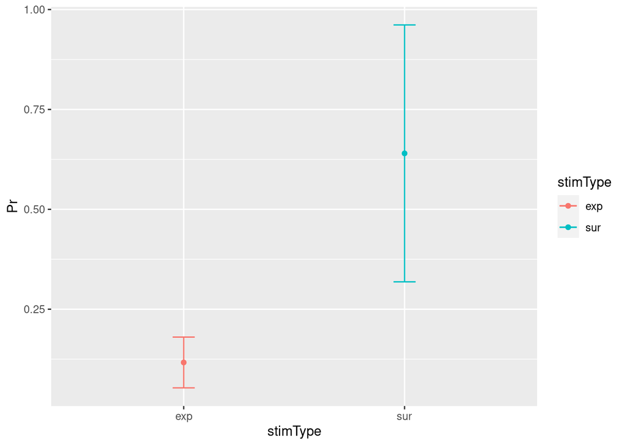

```r
# install.packages("ggplot2")
library(ggplot2) # Load the package

#For plotting I use here 'ggplot2'. Look at the next section (Data visualisation magic)for further information.
ggplot(Easyinfo, aes(x=stimType, y=Pr, colour=stimType)) + # Here you specify the data frame you want to refer to and what should be on the x and y axes...
    geom_errorbar(aes(ymin=Pr-ci, ymax=Pr+ci), width=.1) + # Add here the CI
    geom_line() + # This specifies that we want a simple line
    geom_point() # But with a dot for the mean please...
```

Another very easy way to get the same plot (but with less info and way uglier):

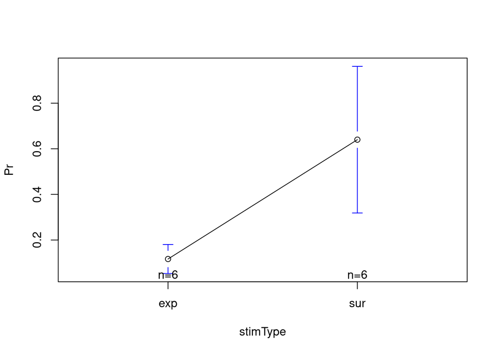

```r
#install.packages("gplots")
library(gplots)
plotmeans(Pr ~ stimType, data = example5)
```

```r
#But this is really only for the lazy ppl - stick with the 1st version if possible.
```

We can use the “summarySEwithin” from the Rmisc package

```r
Easyinfo_within <- summarySEwithin(example5, measurevar = "Pr", within = "stimType") #
```

```
## Automatically converting the following non-factors to factors: stimType
```

```r
Easyinfo_within
```

```
##   stimType N        Pr         sd         se        ci
## 1      exp 6 0.1166667 0.08563488 0.03496029 0.0898683
## 2      sur 6 0.6400000 0.43322050 0.17686153 0.4546370
```

Of course we want to visually inspect these new CIs:

```
## geom_path: Each group consists of only one observation. Do you need to adjust
## the group aesthetic?
```

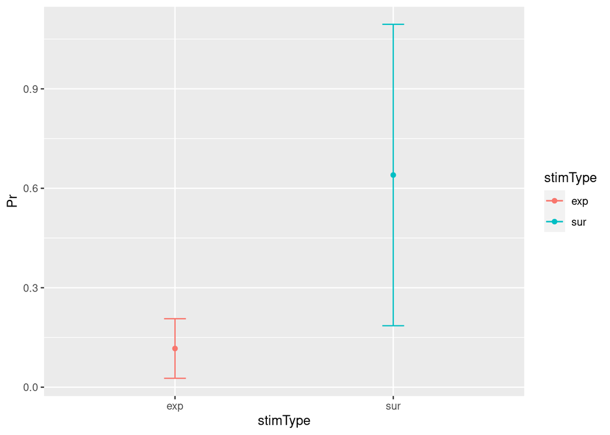

```r
ggplot(Easyinfo_within, aes(x=stimType, y=Pr, colour=stimType)) +
  geom_errorbar(aes(ymin=Pr-ci, ymax=Pr+ci), width=.1) + # Add here the CI
  geom_line() + # This specifies that we want a simple line
  geom_point() # But with a dot for the mean please...
```

#### Data visualisation magic

For plotting I recommend the package [ggplot2](https://rstudio.com/wp-content/uploads/2015/03/ggplot2-cheatsheet.pdf) which has many helpful functions for data visualization and it also gives you the freedom to individualize the plots and to change the parameters the way you want.

##### Boxplots

Other than the plot before, a boxplot will show you by default the median as well as the first and third quartiles (the 25th and 75th percentiles).

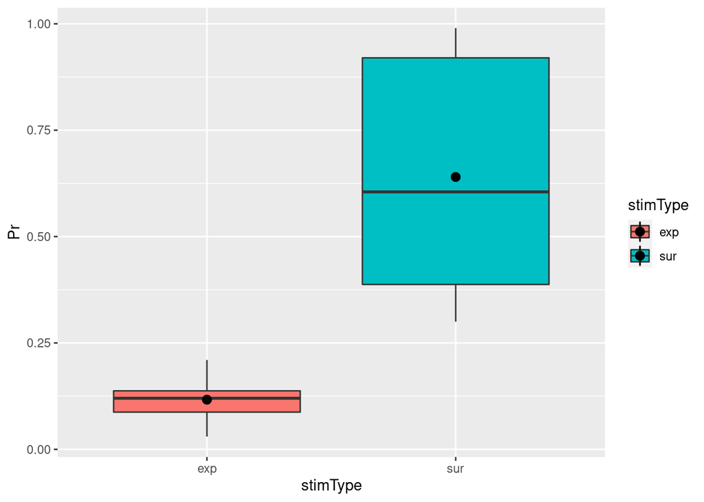

```r
ggplot(example5, aes(stimType, Pr, fill=stimType)) + # `fill=` assignes different colors to the boxplots based on the condition
  geom_boxplot() + # The actual function for a boxplot
  stat_summary(fun.y = "mean") # It might be helpful to add the Mean here as a dot
```

You can change `notch` to `TRUE`. This will give you roughly a 95% CI around the median. This is usually used to compare groups and if the boxes do not overlap you can assume that there is a difference between the two medians.

```
## notch went outside hinges. Try setting notch=FALSE.
## notch went outside hinges. Try setting notch=FALSE.
```

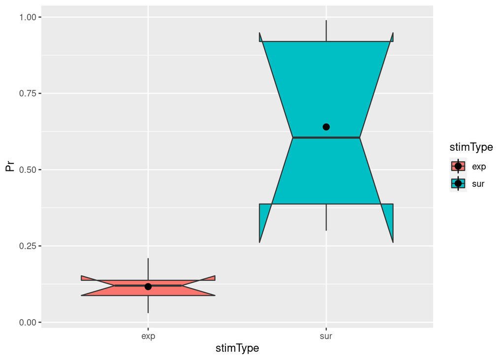

```r
ggplot(example5, aes(stimType, Pr, fill=stimType)) + # `fill=` assignes different colors to the boxplots based on the condition
  geom_boxplot(notch = TRUE) + # The actual function for a boxplot
  stat_summary(fun.y = "mean") # It might be helpful to add the Mean here as a dot
```

##### Adding titles and labels

Awesome – we’ve now got a plot clearly comparing the recognition probability (Pr) of our two different stimulus types. Now that we have that, we might also want to change the axis labels and legend titles to something prettier and more descriptive than the original variable names. We might also want to add a title.

One way of achieving this is by using ggplot’s labs() function. We can simply “add” this to our existing plotting code. For example:

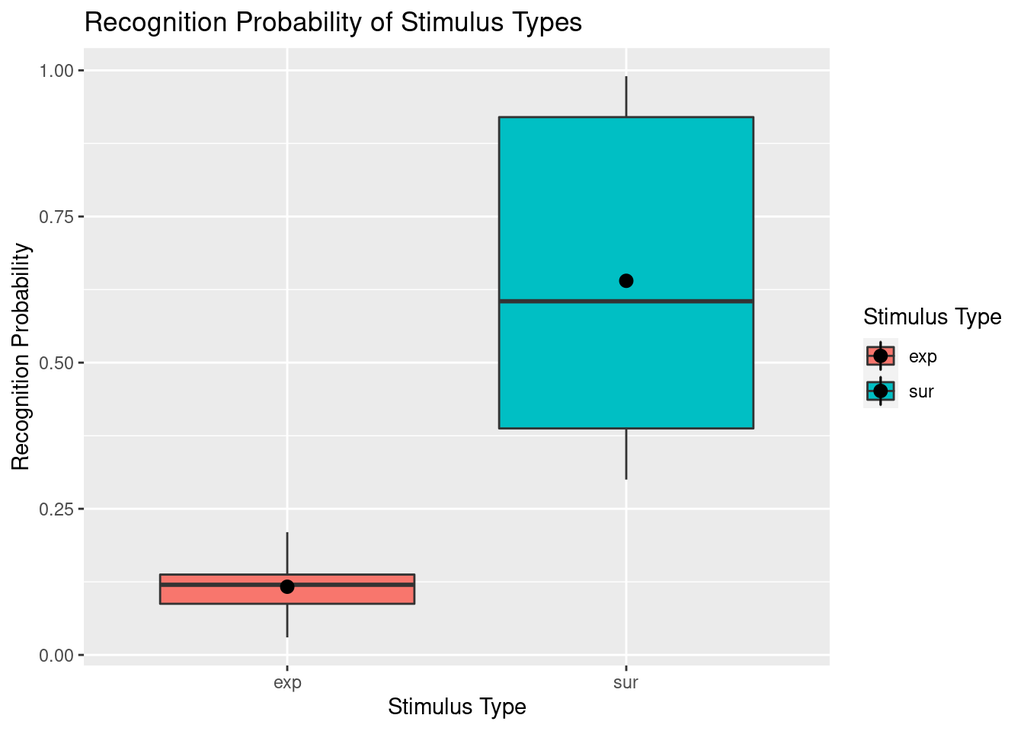

```r
ggplot(example5, aes(stimType, Pr, fill=stimType)) +
  geom_boxplot() +
  stat_summary(fun.y = "mean") +
  labs(title = "Recognition Probability of Stimulus Types", # this bit adds the titles
       fill = "Stimulus Type",
       x = "Stimulus Type",
       y = "Recognition Probability"
  )
```

However, you will notice that this is not completely satisfactory for our x-axis and legend, since the variable stimType that is involved here has the discrete levels “exp” and “sur” that also need to be renamed.

This brings us to a second method of adding labels and titles which allows more fine-tuning. Here, we use scale_x_discrete() and scale_fill_discrete() to customise our x-axis and “fill” (i.e., colour fill legend) respectively.

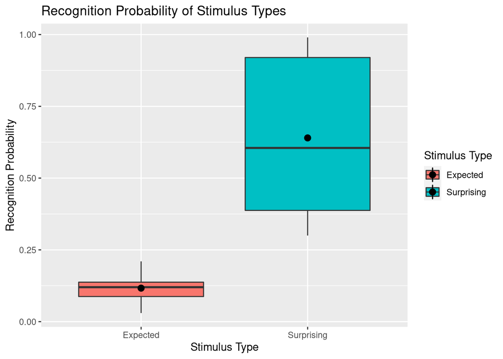

```r
ggplot(example5, aes(stimType, Pr, fill=stimType)) +
  geom_boxplot() +
  stat_summary(fun.y = "mean") +
  labs(title = "Recognition Probability of Stimulus Types",
       y = "Recognition Probability") + # keep labs() function for main title and y axis since thez work fine
  scale_x_discrete(
    "Stimulus Type", # x axis title
    labels = c("exp" = "Expected", "sur" = "Surprising") # change tick mark labels, using syntax OLD NAME = NEW NAME. Note that order specified here does not change order of display
  ) +
  scale_fill_discrete(
   "Stimulus Type", # legend title
   labels = c("exp" = "Expected", "sur" = "Surprising")  # change legend labels, using syntax OLD NAME = NEW NAME.
  )
```

Now we have plots that make reasonable sense for any reader from a quick glance, hurrah!

Of course, there are many, many other ways to customise your data visualisation to your heart’s content – including changing background colours, [text size and positions](https://ggplot2.tidyverse.org/reference/theme.html) of axis labels and titles, and using a colourblind-friendly colour scheme. Some of these things can be very handy, for example, to produce [APA-formatted figures](http://jenrichmond.rbind.io/post/apa-figures/) suitable for inclusion in theses and papers.

##### Spaghetti plots

Sometimes we want to visualise longitudinal data or we want to show which datapoints in two different conditions belong to the same participant. Therefore, we just add the `geom_line()` extension to what we already have created.  
**BUT** keep in mind that too many lines (>6) can be confusing. In that case you might consider to create separate plots.

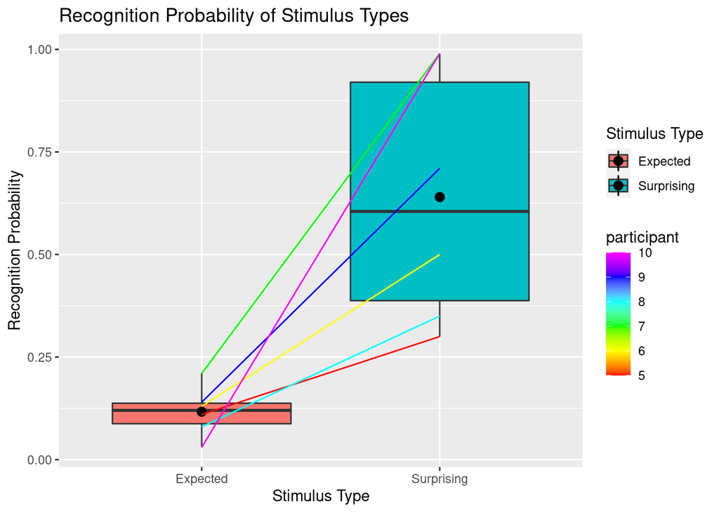

```r
example5$participant<-as.numeric(example5$participant)

ggplot(example5, aes(stimType, Pr, fill=stimType)) +
  geom_boxplot() +
  stat_summary(fun.y = "mean") +
  labs(title = "Recognition Probability of Stimulus Types",
       y = "Recognition Probability") + # keep labs() function for main title and y axis since they work fine
  scale_x_discrete(
    "Stimulus Type", # x axis title
    labels = c("exp" = "Expected", "sur" = "Surprising") # change tick mark labels, using syntax OLD NAME = NEW NAME. Note that order specified here does not change order of display
  ) +
  scale_fill_discrete(
   "Stimulus Type", # legend title
   labels = c("exp" = "Expected", "sur" = "Surprising")  # change legend labels, using syntax OLD NAME = NEW NAME.
  ) +
  geom_line(aes(group=participant, color=participant)) + # this is the relvant part for the spaghettis
  scale_colour_gradientn(colours=rainbow(6)) # You can specify the color palette you want to use for the lines.
```

##### Fancy Barplots

Barplots are convenient if you have for example a categorical variable and another one that represents the amount/number of something. Let’s assume we have 12 participants and we want to visualise how many of them chose an “Otter” as their favourite animal:

```r
example6 = setNames(data.frame(matrix(ncol = 2, nrow = 12))
                    , c("participant", "animal"))
example6$participant = (1:12)
example6$animal = c("Otter",
                 "Lama",
                 "Otter",
                 "Otter",
                 "Lama",
                 "Lama",
                 "Otter",
                 "Bumblebee",
                 "Duck",
                 "Otter",
                 "Otter",
                 "Duck")
example6
```

```
##    participant    animal
## 1            1     Otter
## 2            2      Lama
## 3            3     Otter
## 4            4     Otter
## 5            5      Lama
## 6            6      Lama
## 7            7     Otter
## 8            8 Bumblebee
## 9            9      Duck
## 10          10     Otter
## 11          11     Otter
## 12          12      Duck
```

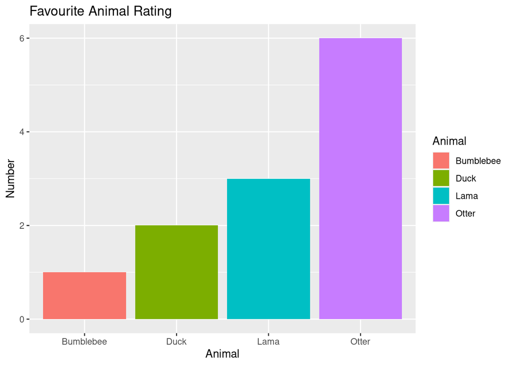

```r
ggplot(example6, aes(animal, fill=animal)) +
  geom_bar() + # This gives you the barplot
  labs(title = "Favourite Animal Rating",
       y = "Number") +
  scale_x_discrete(
    "Animal") +
  scale_fill_discrete(
   "Animal")
```

Nice!! - naturally, the **Otter** is clearly the [most favourite animal!](https://i.kym-cdn.com/photos/images/original/001/550/716/eff.jpg)

##### Visualising correlations with scatter plots

To demonstrate how we can visualise correlation, let us consider a second continuous variable – reaction time (rt) – in addition to our existing continuous variable Pr.

```r
example7 <- example5
example7$rt <- c(1303,
                900,
                1193,
                1000,
                1090,
                690,
                1393,
                1121,
                970,
                988,
                1440,
                793)
```

Let’s say that we are interested in assessing whether participants’ recognition probability are correlated with their reaction time. An easy way to get a glimpse of this is using a scatterplot, by using `geom_point()`.

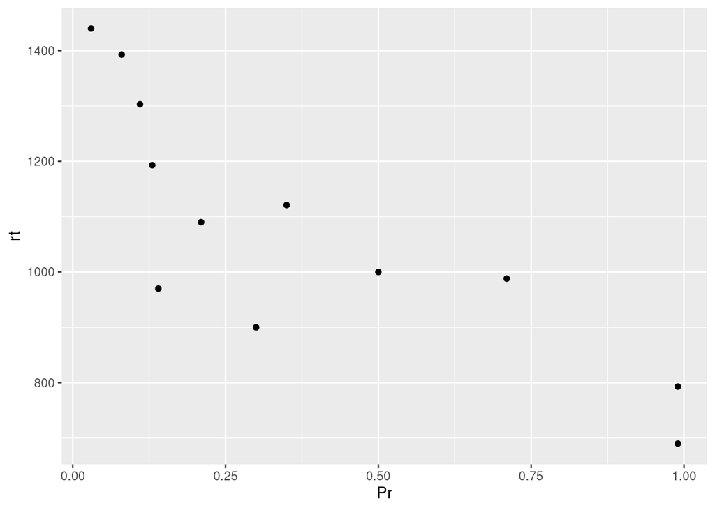

```r
ggplot(example7, aes(x=Pr , y=rt)) +
  geom_point() # makes a scatter plot using x and y variables specified in aes()
```

Okay, it looks like maybe something is going on here. While we could try and fit a single regression line through the above data points, it could also be more informative to see whether this relationship differs by some condition – for instance, stimulus type in our case.

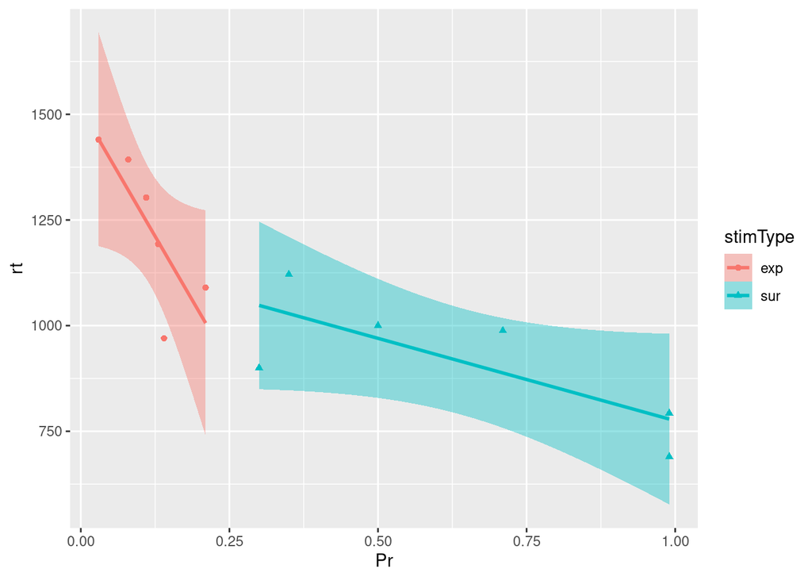

```r
ggplot(example7, aes(x=Pr, y=rt, color=stimType, shape=stimType)) +
  geom_point() +
  geom_smooth(method=lm, aes(fill=stimType))
```

Here, taking a closer look at the relationship between our two continuous variables assessed revealed that they were of a similar nature between the levels of our condition (stimulus type). That is, for both stimulus conditions, Pr and rt were negatively correlated, as was congruent with the overall relationship suggested by our first scatterplot.

In less straightforward cases, simply assessing relationships between two variables without considering subgroups, as we’d done in the first scatterplot, can be misleading. (See [Simpson’s Paradox] (https://rpubs.com/shampjeff/blog_post_2).) Such scenarios highlight why it can be useful – and important – to break down your visualisation by subgroups through harnessing the power of R!